# New Model Results and Explanations

#### Fitting to the full training set

The following fits the random forest with the optimal parameters found in the previous step, to the full training set and tests it on the held-out set.

```r
# ============= Set up parameters:
final.grid <- data.frame(.mtry = 4, # contains the optimal parameters
                         .splitrule = "gini",
                         .min.node.size = 10)

final.control <- trainControl(method = "none", # tells train() to fit the model to the full data without any partitioning
                              verboseIter = TRUE,
                              classProbs = TRUE,
                              summaryFunction = twoClassSummary)

# ============= Fit the model:
set.seed(1)
rf.fit <- train(did.exceed ~ .,
                data = train1,
                method = "ranger",
                tuneGrid = final.grid,
                trControl = final.control,
                num.trees = 1000,
                importance = "impurity",
                metric = "ROC")
```

#### Assessing performance

```r
# ============= Compute predictions:
rf.preds <- predict(rf.fit, newdata = test, type = "prob")

rf.preds <- rf.preds %>%
  mutate(prediction = ifelse(yes > 0.50, "yes", "no")) %>%
  mutate(actual = test$did.exceed)
```

The model achieved a classification accuracy of 91.107%.

```r
# ROC/AUC
roc.metric <- roc(predictions = rf.preds$yes,
                  labels = as.factor(ifelse(as.character(test$did.exceed) == "yes", 1, 0)))
auc.metric <- auc(roc.metric)
```

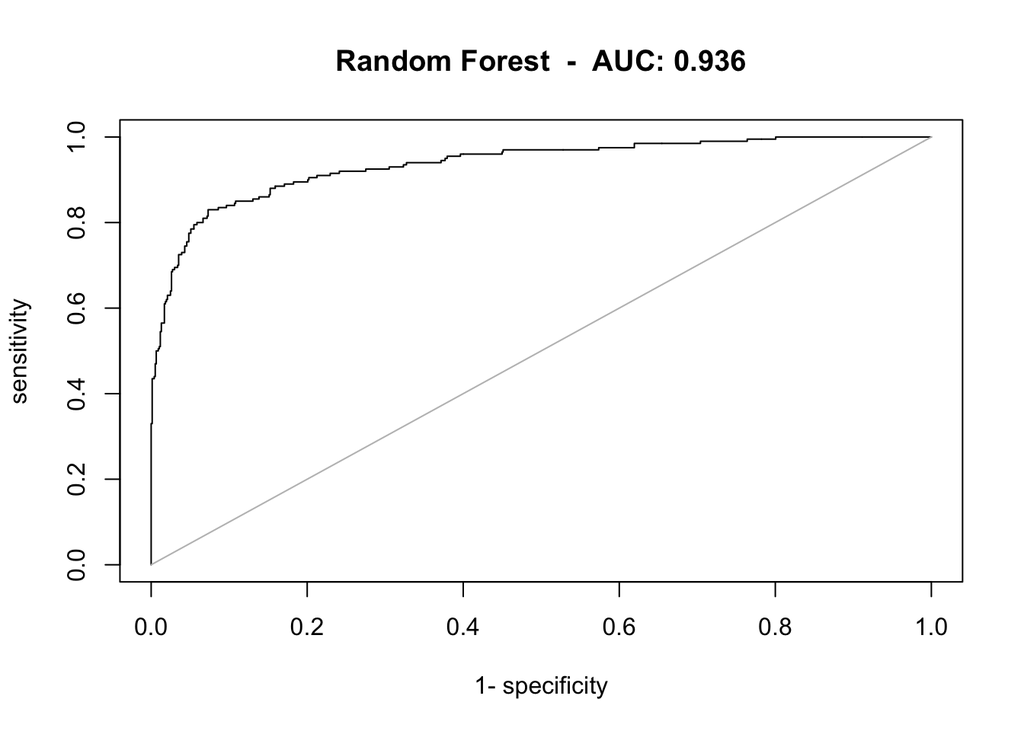

```r
# sensitivity: true positive rate - ability of the model to correctly identify wind event days
# specificity: true negative rate - ability of the model to correctly identify non-wind event days
plot(roc.metric, main = paste("Random Forest  -  AUC:", round(auc.metric, 4)))
```

The following is a confusion matrix of the model’s predictions, as well as calculated precision and recall.

```r
# precision = 140 / (26 + 140) = 0.843
# out of all of the days that are being predicted as wind event days, 84.3% of them are actually wind event days

# recall = 140 / (60 + 140) = 0.70
# out of all of the days that truly were wind event days, 70% of them were classified correctly

table(rf.preds$prediction, rf.preds$actual)
```

```
##
##        no yes
##   no  741  60
##   yes  26 140
```

# XGBoosts

#### Parameter tuning

```r
# parameter tuning
xgb.tune.grid <- expand.grid(nrounds = c(500, 1000),
                             max_depth = c(3, 6, 10),
                             eta = 0.3,
                             gamma = 1,
                             min_child_weight = 1,
                             colsample_bytree = c(0.5, 0.8),
                             subsample = c(0.5, 0.8))

tune.control <- trainControl(method = "cv",
                             number = 5,
                             verboseIter = TRUE,
                             classProbs = TRUE,
                             summaryFunction = twoClassSummary)

xgb.tune <- train(did.exceed ~ .,
                  data = train1,
                  method = "xgbTree",
                  tuneGrid = xgb.tune.grid,
                  trControl = tune.control,
                  importance = "impurity",
                  metric = "ROC")
```

The following displays tuning results and variable importance. Parameters that lead to the best performance (with an ROC of 0.946) were:

```r
knitr::kable(xgb.tune$bestTune) %>%
  kable_styling(full_width = FALSE)
```

|  | nrounds | max_depth | eta | gamma | colsample_bytree | min_child_weight | subsample |
| --- | --- | --- | --- | --- | --- | --- | --- |
| 23 | 500 | 10 | 0.3 | 1 | 0.8 | 1 | 0.8 |

```r
knitr::kable(xgb.tune$results, caption = "XGBoost tuning results") %>%
  kable_styling(full_width = FALSE)
```

XGBoost tuning results

|  | eta | max_depth | gamma | colsample_bytree | min_child_weight | subsample | nrounds | ROC | Sens | Spec | ROCSD | SensSD | SpecSD |
| --- | --- | --- | --- | --- | --- | --- | --- | --- | --- | --- | --- | --- | --- |
| 1 | 0.3 | 3 | 1 | 0.5 | 1 | 0.5 | 500 | 0.9204016 | 0.9458819 | 0.6857912 | 0.0201916 | 0.0101970 | 0.0743256 |
| 3 | 0.3 | 3 | 1 | 0.5 | 1 | 0.8 | 500 | 0.9186082 | 0.9490015 | 0.7077441 | 0.0196889 | 0.0077910 | 0.0662282 |
| 5 | 0.3 | 3 | 1 | 0.8 | 1 | 0.5 | 500 | 0.9366799 | 0.9375594 | 0.7151515 | 0.0113128 | 0.0097844 | 0.0434930 |
| 7 | 0.3 | 3 | 1 | 0.8 | 1 | 0.8 | 500 | 0.9429794 | 0.9448402 | 0.7151515 | 0.0088240 | 0.0060240 | 0.0395103 |
| 9 | 0.3 | 6 | 1 | 0.5 | 1 | 0.5 | 500 | 0.9183694 | 0.9469290 | 0.6931313 | 0.0157641 | 0.0085672 | 0.0561783 |
| 11 | 0.3 | 6 | 1 | 0.5 | 1 | 0.8 | 500 | 0.9207457 | 0.9438040 | 0.7004040 | 0.0172152 | 0.0100472 | 0.0807500 |
| 13 | 0.3 | 6 | 1 | 0.8 | 1 | 0.5 | 500 | 0.9412304 | 0.9427623 | 0.7041751 | 0.0126958 | 0.0082785 | 0.0453357 |
| 15 | 0.3 | 6 | 1 | 0.8 | 1 | 0.8 | 500 | 0.9433595 | 0.9437986 | 0.7004040 | 0.0131857 | 0.0107277 | 0.0732362 |
| 17 | 0.3 | 10 | 1 | 0.5 | 1 | 0.5 | 500 | 0.9197553 | 0.9490069 | 0.6931313 | 0.0148258 | 0.0024379 | 0.0617832 |
| 19 | 0.3 | 10 | 1 | 0.5 | 1 | 0.8 | 500 | 0.9247123 | 0.9479598 | 0.7004714 | 0.0208853 | 0.0074423 | 0.0704040 |
| 21 | 0.3 | 10 | 1 | 0.8 | 1 | 0.5 | 500 | 0.9428338 | 0.9406844 | 0.7042424 | 0.0112207 | 0.0108154 | 0.0386646 |
| 23 | 0.3 | 10 | 1 | 0.8 | 1 | 0.8 | 500 | 0.9459696 | 0.9469182 | 0.7042424 | 0.0171165 | 0.0086307 | 0.0407460 |
| 2 | 0.3 | 3 | 1 | 0.5 | 1 | 0.5 | 1000 | 0.9181978 | 0.9448456 | 0.6969697 | 0.0205797 | 0.0108204 | 0.0482951 |
| 4 | 0.3 | 3 | 1 | 0.5 | 1 | 0.8 | 1000 | 0.9188634 | 0.9458873 | 0.6967677 | 0.0198515 | 0.0079175 | 0.0753741 |
| 6 | 0.3 | 3 | 1 | 0.8 | 1 | 0.5 | 1000 | 0.9355498 | 0.9344506 | 0.7224916 | 0.0089979 | 0.0107376 | 0.0498034 |
| 8 | 0.3 | 3 | 1 | 0.8 | 1 | 0.8 | 1000 | 0.9433319 | 0.9448402 | 0.7152189 | 0.0083707 | 0.0047671 | 0.0289781 |
| 10 | 0.3 | 6 | 1 | 0.5 | 1 | 0.5 | 1000 | 0.9175199 | 0.9417314 | 0.6931313 | 0.0158385 | 0.0076828 | 0.0617832 |
| 12 | 0.3 | 6 | 1 | 0.5 | 1 | 0.8 | 1000 | 0.9211868 | 0.9448456 | 0.7113131 | 0.0167928 | 0.0087402 | 0.0743931 |
| 14 | 0.3 | 6 | 1 | 0.8 | 1 | 0.5 | 1000 | 0.9422639 | 0.9469182 | 0.7114478 | 0.0121936 | 0.0107321 | 0.0490832 |
| 16 | 0.3 | 6 | 1 | 0.8 | 1 | 0.8 | 1000 | 0.9436292 | 0.9448402 | 0.7150168 | 0.0136820 | 0.0114557 | 0.0671553 |
| 18 | 0.3 | 10 | 1 | 0.5 | 1 | 0.5 | 1000 | 0.9201782 | 0.9490069 | 0.6894949 | 0.0173105 | 0.0024379 | 0.0611407 |
| 20 | 0.3 | 10 | 1 | 0.5 | 1 | 0.8 | 1000 | 0.9222925 | 0.9489961 | 0.7004714 | 0.0211873 | 0.0093910 | 0.0667897 |
| 22 | 0.3 | 10 | 1 | 0.8 | 1 | 0.5 | 1000 | 0.9426892 | 0.9406844 | 0.6969697 | 0.0122349 | 0.0108154 | 0.0226767 |
| 24 | 0.3 | 10 | 1 | 0.8 | 1 | 0.8 | 1000 | 0.9454911 | 0.9448348 | 0.7041751 | 0.0173215 | 0.0087992 | 0.0505093 |

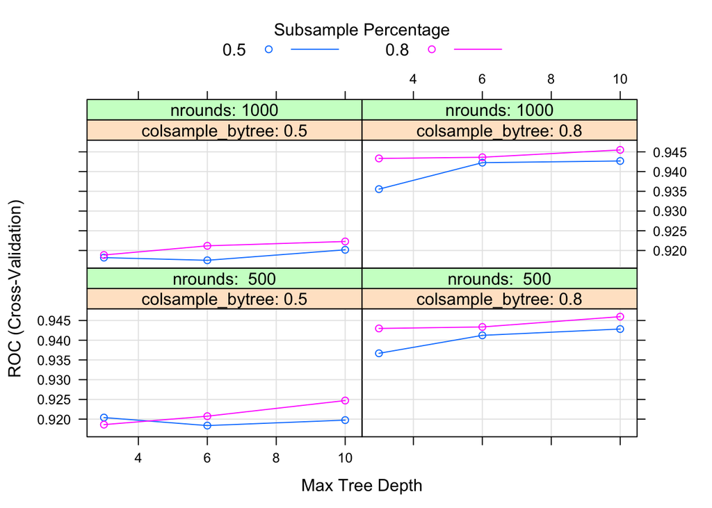

```r
plot(xgb.tune)
```

The following assesses variable importance. Interestingly, it appears that the variables considered “important” in the random forests are not important here (e.g. `wind.in.range.cdf` is much further down in the plot than it is with the random forest).

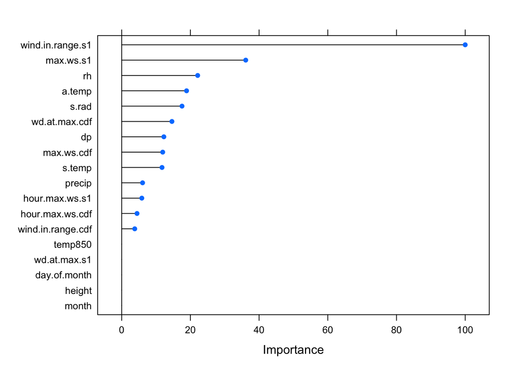

```r
plot(varImp(xgb.tune))
```

#### Fitting to the full training set

```r
# fit to full training set
xgb.final <- train(did.exceed ~ .,
                   data = train1,
                   method = "xgbTree",
                   tuneGrid = xgb.tune$bestTune,
                   trControl = trainControl(method = "none",
                                            verboseIter = TRUE,
                                            classProbs = TRUE,
                                            summaryFunction = twoClassSummary),
                   importance = "impurity",
                   metric = "ROC")
```

#### Assessing performance

```r
# # assess performance
xgb.preds <- predict(xgb.final, newdata = test, type = "prob") %>%
  as.data.frame() %>%
  mutate(prediction = ifelse(yes > 0.50, "yes", "no")) %>%
  mutate(actual = test$did.exceed)

# classification accuracy
mean(xgb.preds$actual == xgb.preds$prediction) # 0.8955533

# ROC/AUC
xgb.roc.metric <- roc(predictions = xgb.preds$yes,
                      labels = as.factor(ifelse(as.character(test$did.exceed) == "yes", 1, 0)))
xgb.auc.metric <- auc(xgb.roc.metric)
```

The XGBoost fit to the full training set and tested on the held-out set achieved a classification accuracy of 89.555%, and an ROC/AUC of:

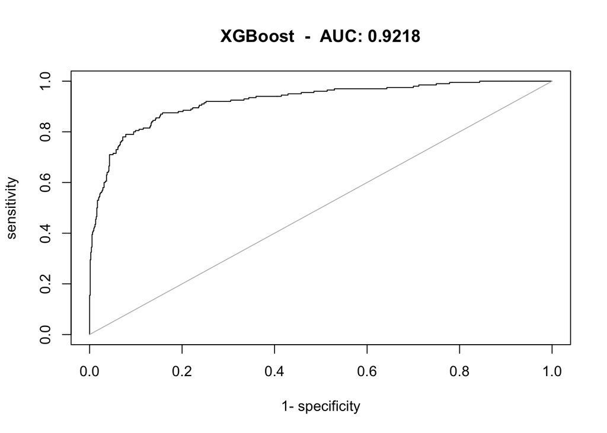

```r
plot(xgb.roc.metric, main = paste("XGBoost  -  AUC:", round(xgb.auc.metric,4)))
```

Confusion matrix of the model’s predictions:

```r
table(xgb.preds$prediction, xgb.preds$actual)
```

```
##
##        no yes
##   no  714  48
##   yes  53 152
```

# Support vector machines

The following code tunes and fits support vector machines with polynomial and linear kernels.

**Note on SVM predicted class probabilities:** SVMs don’t directly output predictions of probability. Instead, with the function used in this file, probabilities are computed based on the observation’s distance from the hyperplane (the plane that partitions the data into classes) and a logistic distribution.

#### Polynomial kernel

##### Parameter tuning

```r
# tuning svm with polynomial kernel
tune.out <- tune(svm, did.exceed ~ .,
                 data = train1,
                 kernel = "polynomial",
                 degree = 2,
                 ranges = list(cost = c(.01, .1, .5, 1, 5, 7, 10)),
                 probability = TRUE)
```

```r
summary(tune.out)
```

```
##
## Parameter tuning of 'svm':
##
## - sampling method: 10-fold cross validation
##
## - best parameters:
##  cost
##     5
##
## - best performance: 0.09228954
##
## - Detailed performance results:
##    cost      error dispersion
## 1  0.01 0.18225806 0.03314147
## 2  0.10 0.14009966 0.02370138
## 3  0.50 0.11901390 0.02286571
## 4  1.00 0.10767768 0.01902287
## 5  5.00 0.09228954 0.02500047
## 6  7.00 0.09957383 0.02180706
## 7 10.00 0.09796092 0.02229673
```

##### Fitting to the full training set

```r
# svm with tuned parameter on full training set
svm.tuned <- svm(did.exceed ~ .,
                 data = train1,
                 kernel = "polynomial",
                 degree = 2,
                 cost = tune.out$best.parameters$cost,
                 probability = TRUE) # tuned cost parameter
```

##### Assessing performance

```r
# ------------------------------------------
# assessing training error + ROC/AUC metric
# ------------------------------------------
train.preds <- predict(svm.tuned, newdata = train1, probability = TRUE)

# classification accuracy
mean(train.preds == train1$did.exceed)

# ROC/AUC
train.roc <- roc(predictions = attr(train.preds, "probabilities")[ , 1],
                 labels = as.factor(ifelse(as.character(train1$did.exceed) == "yes", 1, 0)))
train.auc <- auc(train.roc)
```

The SVM achieved a training classification accuracy of 92.389%. Training ROC/AUC is:

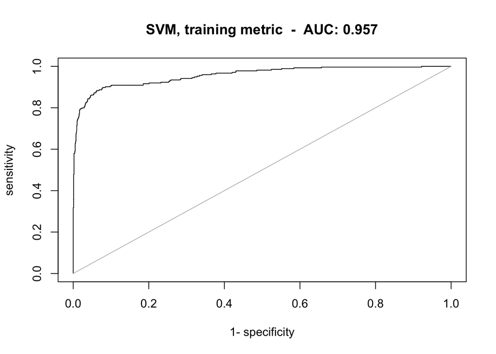

```r
plot(train.roc, main = paste("SVM, training metric  -  AUC:", round(train.auc, 3)))
```

```r
# --------------------------------------
# assessing test error + ROC/AUC metric
# --------------------------------------
test.preds <- predict(svm.tuned, newdata = test, probability = TRUE)

# classification accuracy
mean(test.preds == test$did.exceed) #  0.8738366

# ROC/AUC
test.roc <- roc(predictions = attr(test.preds, "probabilities")[ , 1],
                labels = as.factor(ifelse(as.character(test$did.exceed) == "yes", 1, 0)))
test.auc <- auc(test.roc)
```

Tested on the held-out set, the SVM achieved a classification accuracy of 88.728%. ROC/AUC on the test set was:

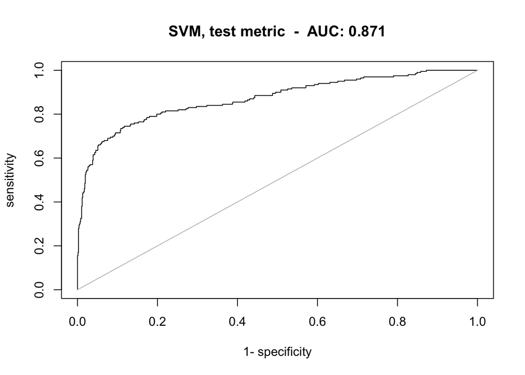

```r
plot(test.roc, main = paste("SVM, test metric  -  AUC:", round(test.auc, 3)))
```

#### Linear kernel

##### Parameter tuning

```r
# tuning svm with linear kernel
tune.out.linear <- tune(svm, did.exceed ~ .,
                        data = train1,
                        kernel = "linear",
                        ranges = list(cost = c(0.001, .01, .1, .5, 1, 5, 7, 10)),
                        probability = TRUE)
```

```r
summary(tune.out.linear)
```

```
##
## Parameter tuning of 'svm':
##
## - sampling method: 10-fold cross validation
##
## - best parameters:
##  cost
##     5
##
## - best performance: 0.08664437
##
## - Detailed performance results:
##    cost      error dispersion
## 1 1e-03 0.12306583 0.03082172
## 2 1e-02 0.09068975 0.02991365
## 3 1e-01 0.08825728 0.02299978
## 4 5e-01 0.08825728 0.02567681
## 5 1e+00 0.08826383 0.02709119
## 6 5e+00 0.08664437 0.02614750
## 7 7e+00 0.08745083 0.02688497
## 8 1e+01 0.08745083 0.02688497
```

##### Fitting to the full training set

```r
svm.tuned.linear <- svm(did.exceed ~ .,
                        data = train1,
                        kernel = "linear",
                        cost = tune.out.linear$best.parameters$cost,
                        probability = TRUE)
```

##### Assessing performance

```r
# ------------------------------------------
# assessing training error + ROC/AUC metric
# ------------------------------------------
train.preds.linear <- predict(svm.tuned.linear, newdata = train1, probability = TRUE)

# classification accuracy
mean(train.preds.linear == train1$did.exceed)

# ROC/AUC
train.roc.linear <- roc(predictions = attr(train.preds.linear, "probabilities")[ , 1],
                        labels = as.factor(ifelse(as.character(train1$did.exceed) == "yes", 1, 0)))
train.auc.linear <- auc(train.roc.linear)

# --------------------------------------
# assessing test error + ROC/AUC metric
# --------------------------------------
test.preds.linear <- predict(svm.tuned.linear, newdata = test, probability = TRUE)

# classification accuracy
mean(test.preds.linear == test$did.exceed)

# ROC/AUC
test.roc.linear <- roc(predictions = attr(test.preds.linear, "probabilities")[ , 1],
                       labels = as.factor(ifelse(as.character(test$did.exceed) == "yes", 1, 0)))
test.auc.linear <- auc(test.roc.linear)
```

- Classification accuracy on the training set: 0.918
- Classification accuracy on the test set: 0.884

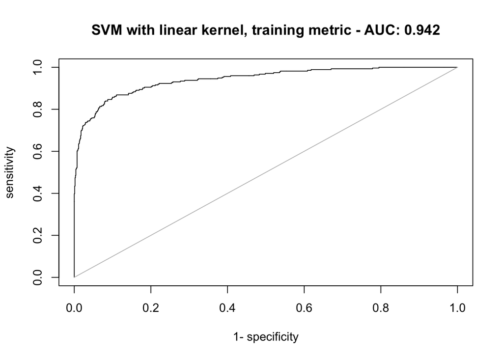

```r
plot(train.roc.linear, main = paste("SVM with linear kernel, training metric - AUC:", round(train.auc.linear, 3))) # 0.841
```

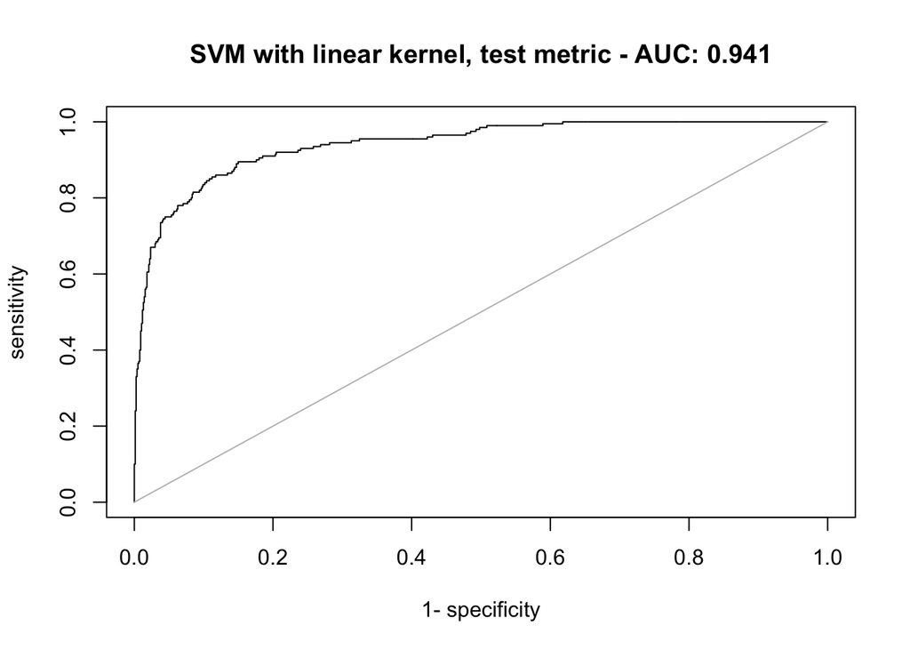

```r
plot(test.roc.linear, main = paste("SVM with linear kernel, test metric - AUC:", round(test.auc.linear, 3)))
```

#### Note about ROC/AUC for SVMs

I am a little skeptical about the ROC/AUC for these SVMs. Compared to the test set performance of other models, I am a little hestitant about trusting that the SVM with the linear kernel performed so well on the test set. Classification accuracy for this model was just 88.418%, which is actually lower than the accuracy for the SVM with the polynomial kernel, 88.728%, that achieved a much lower AUC of 0.871. To look more into this matter, I used the `confusionMatrix()` function from the caret package for more details on model performance - since this function does not require class probabiliites. The following table compares the SVM with a polynomial vs. linear kernel.

```r
svm.linear.cm <- confusionMatrix(data = test.preds.linear,
                                 reference = test$did.exceed)
svm.poly.cm <- confusionMatrix(data = test.preds,
                               reference = test$did.exceed)

# format metrics
knitr::kable(data.frame(Metric = names(svm.linear.cm$byClass),
           'Linear Kernel' = unname(round(svm.linear.cm$byClass, 3)),
           'Polynomial Kernel' = unname(round(svm.poly.cm$byClass, 3))),
           caption = "Metric comparison") %>%
  kableExtra::kable_styling(full_width = F) %>%
  kableExtra::row_spec(c(1, 2, 5, 6, 11), background = "yellow")
```

Metric comparison

| Metric | Linear.Kernel | Polynomial.Kernel |
| --- | --- | --- |
| Sensitivity | 0.896 | 0.961 |
| Specificity | 0.840 | 0.605 |
| Pos Pred Value | 0.955 | 0.903 |
| Neg Pred Value | 0.677 | 0.801 |
| Precision | 0.955 | 0.903 |
| Recall | 0.896 | 0.961 |
| F1 | 0.925 | 0.931 |
| Prevalence | 0.793 | 0.793 |
| Detection Rate | 0.710 | 0.762 |
| Detection Prevalence | 0.744 | 0.844 |
| Balanced Accuracy | 0.868 | 0.783 |

From the table above, one possible reason for the difference in ROC/AUC scores is that linear kernel’s specificity (true negative rate) is much higher than it is for the model with the polynomial kernel. So, the SVM with the linear kernel does a much better job at classifying the days in which PM10 exceeded the standard (the model with the polynomial kernel only predicted 60.5% correctly).

Also, after looking into the `svm` function documentation, I’m still confused about how probabilities are being computed and what exactly happens when `probability = TRUE` is included in the predict function call (`probability = TRUE` vs. `probability = FALSE` lead to slightly different class predictions). Because I’m hestitant about the ROC/AUC for SVMs, I’ve included output from `confusionMatrix()` for all models to be able to compare other metrics, besides classification accuracy and ROC/AUC, in the Comparing models section.

# Decision tree

```r
treefit <- tree(did.exceed ~ ., data = train1, split = "gini")
summary(treefit)

# CV to determine optimal size of tree
cv.treefit <- cv.tree(treefit, FUN = prune.misclass)
plot(cv.treefit) # size = 9 did best

pruned.tree <- prune.misclass(treefit, best = 9)
summary(pruned.tree) #  0.09636 = 119 / 1235
plot(pruned.tree)
text(pruned.tree)

# re-train again, using only variables in pruned tree
vars <- unique(as.character(pruned.tree$frame[ , 1]))
vars <- vars[-which(vars == "<leaf>")]
new.train <- train1[ , c("did.exceed", vars)]

new.tree <- tree(did.exceed ~ ., data = new.train, split = "gini")
summary(new.tree) #  0.08259 = 102 / 1235

# predict on test data
tree.preds <- predict(new.tree, newdata = test) %>%
  as.data.frame() %>%
  mutate(prediction = ifelse(yes > 0.50, "yes", "no")) %>%
  mutate(actual = test$did.exceed)

# classification accuracy
mean(tree.preds$actual == tree.preds$prediction) # 0.8924509

# ROC/AUC
roc.metric.tree <- roc(predictions = tree.preds$yes,
                       labels = as.factor(ifelse(as.character(test$did.exceed) == "yes", 1, 0)))
auc.metric.tree <- auc(roc.metric.tree)
```

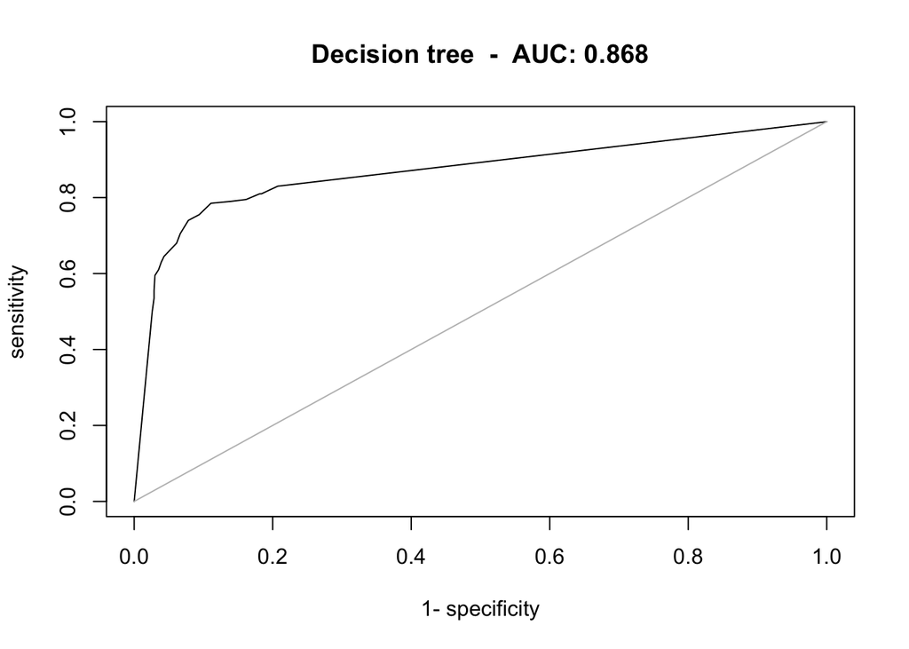

```r
plot(roc.metric.tree, main = paste("Decision tree  -  AUC:", round(auc.metric.tree, 3)))
```

```r
# confusion matrix
# precision = 129 / (33 + 129) = 0.796
# out of all that are being classified as high pm10 days - 79.6% are actually high pm10 days
# recall = 129 / (71 + 129) = 0.645
# out of all days that are actually high pm10, 64.5% are actually being classified as such

table(tree.preds$prediction, tree.preds$actual)
```

```
##
##        no yes
##   no  734  71
##   yes  33 129
```

# Comparing models

#### Model comparisons based on ROC/AUC

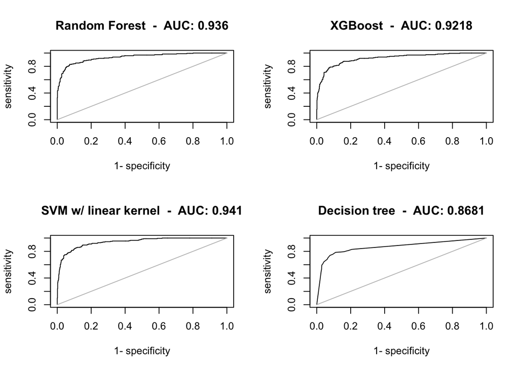

```r
par(mfrow = c(2, 2))
plot(roc.metric, main = paste("Random Forest  -  AUC:", round(auc.metric, 4)))
plot(xgb.roc.metric, main = paste("XGBoost  -  AUC:", round(xgb.auc.metric,4)))
plot(test.roc.linear, main = paste("SVM w/ linear kernel  -  AUC:", round(test.auc.linear, 3)))
plot(roc.metric.tree, main = paste("Decision tree  -  AUC:", round(auc.metric.tree, 4)))
```

#### Model comparisons based on other metrics

```r
rf.cm <- confusionMatrix(rf.preds$prediction, reference = test$did.exceed)
xgb.cm <- confusionMatrix(xgb.preds$prediction, reference = test$did.exceed)
tree.cm <- confusionMatrix(tree.preds$prediction, reference = test$did.exceed)

# format metrics
knitr::kable(data.frame(Metric = names(svm.linear.cm$byClass),
           'Linear Kernel' = unname(round(svm.linear.cm$byClass, 3)),
           'Polynomial Kernel' = unname(round(svm.poly.cm$byClass, 3)),
           'Random forest' = unname(round(rf.cm$byClass, 3)),
           'XGBoost' = unname(round(xgb.cm$byClass, 3)),
           'Decision tree' = unname(round(tree.cm$byClass, 3)))) %>%
  kableExtra::kable_styling(full_width = F) %>%
  kableExtra::row_spec(c(1, 2, 5, 6, 11), background = "yellow")
```

| Metric | Linear.Kernel | Polynomial.Kernel | Random.forest | XGBoost | Decision.tree |
| --- | --- | --- | --- | --- | --- |
| Sensitivity | 0.896 | 0.961 | 0.966 | 0.931 | 0.957 |
| Specificity | 0.840 | 0.605 | 0.700 | 0.760 | 0.645 |
| Pos Pred Value | 0.955 | 0.903 | 0.925 | 0.937 | 0.912 |
| Neg Pred Value | 0.677 | 0.801 | 0.843 | 0.741 | 0.796 |
| Precision | 0.955 | 0.903 | 0.925 | 0.937 | 0.912 |
| Recall | 0.896 | 0.961 | 0.966 | 0.931 | 0.957 |
| F1 | 0.925 | 0.931 | 0.945 | 0.934 | 0.934 |
| Prevalence | 0.793 | 0.793 | 0.793 | 0.793 | 0.793 |
| Detection Rate | 0.710 | 0.762 | 0.766 | 0.738 | 0.759 |
| Detection Prevalence | 0.744 | 0.844 | 0.828 | 0.788 | 0.832 |
| Balanced Accuracy | 0.868 | 0.783 | 0.833 | 0.845 | 0.801 |

Based on the table above, it also appears that the SVM with the linear kernel performed the best. Below are definitions of some metrics featured above.

- Sensitivity: True positive rate - if the classifier is able to accurately identify days in which PM10 did not exceed the standard
- Specificity: True negative rate - if the classifier is able to accurately identify days in which PM10 did exceed the standard
- Precision: Of the days in which it was predicted that PM10 exceeded the standard, this is the percentage of those days that were true (days that PM10 actually did exceed the standard).
- Recall: Of all days that PM10 actually did exceed the standard, this is the percentage of those days that the classifier predicted correctly (predicted that PM10 exceeded the standard).
- Balanced accuracy: Good for imbalanced data sets - computed as: `(sensitivity + specificity)/2`

This [link](https://topepo.github.io/caret/measuring-performance.html), under Measures for Predicted Classes, contains more information about each of these metrics.